# Amazon Data Scientist Mock Interview

The goal of this data challenge is to assess the candidate's skills in data manipulation, feature preprocessing and engineering, customer segmentation, and extracting business insights. The candidate will be asked to answer a series of questions using SQL and Python.

## Data Tables

*Customers*:

- Customer_Id: unique identifier for each customer
- Age: customer age, ranging from 18 to 70
- Gender: gender of the customer, F stands for female and M stands for male
- Location: location of the customer, represented by city A to D
- Tenure: number of years since the customer signed up
- Avg_Session_Duration_min: the average time that each customer spend on each session in minutes
- No_of_Purchases: the total number of purchases this customer has made

*Products:*

*Customer_behavior:*

- Customer_Id: unique identifier for each customer
- Product_Id: unique identifier for each product
- Clicked: indicator of whether this customer has clicked on the link to this product, meaning that this customer viewed the product
- Added_to_Cart: indicator of whether this customer added this product to their shopping cart
- Purchased(TARGET VARIABLE): indicator of whether the customer purchased this product (0 means not purchased and 1 means purchased)

```python
import pandas as pd
import numpy as np

customers_path = 'https://storage.googleapis.com/datalynn-datasets/interview-challenge/e-commerce-and-online-service/Amazon_Segmentation/customers.csv'
products_path = 'https://storage.googleapis.com/datalynn-datasets/interview-challenge/e-commerce-and-online-service/Amazon_Segmentation/products.csv'
customer_behavior_path = 'https://storage.googleapis.com/datalynn-datasets/interview-challenge/e-commerce-and-online-service/Amazon_Segmentation/customer_behavior.csv'

customers = pd.read_csv(customers_path)
products = pd.read_csv(products_path)
customer_behavior = pd.read_csv(customer_behavior_path)
```

```python
customers.head()
```

|  | Customer_Id | Age | Gender | Location | Tenure | Avg_Session_Duration_min | No_of_Purchases |
| --- | --- | --- | --- | --- | --- | --- | --- |
| 0 | 0 | 35 | F | City_B | 4 | 16.294556 | 87 |
| 1 | 1 | 44 | F | City_B | 9 | 11.181317 | 68 |
| 2 | 2 | 38 | M | City_D | 1 | 5.384545 | 19 |
| 3 | 3 | 35 | M | City_A | 4 | 23.113886 | 25 |
| 4 | 4 | 30 | M | City_C | 2 | 16.425295 | 34 |

```python
products.head()
```

|  | Product_Id | Category | Brand | Price | Rating |
| --- | --- | --- | --- | --- | --- |
| 0 | 0 | Groceries | Brand_G1 | 8.074025 | 3.8 |
| 1 | 1 | Clothing | Brand_C3 | 33.990447 | 4.2 |
| 2 | 2 | Groceries | Brand_G3 | 13.514675 | 3.4 |
| 3 | 3 | Electronic | Brand_E2 | 369.359531 | 4.0 |
| 4 | 4 | Groceries | Brand_G3 | 12.930961 | 3.4 |

```python
customer_behavior.head()
```

|  | Customer_Id | Product_Id | Clicked | Added_to_Cart | Purchased |
| --- | --- | --- | --- | --- | --- |
| 0 | 0 | 216 | 1 | 1 | 0 |
| 1 | 0 | 188 | 0 | 0 | 0 |
| 2 | 0 | 445 | 1 | 0 | 0 |
| 3 | 0 | 479 | 1 | 1 | 1 |
| 4 | 0 | 304 | 1 | 1 | 1 |

## 1 SQL Questions: In this section, we will test your ability to write SQL codes. Below is the setup code block.

```python
import sqlite3

# Create a connection
conn = sqlite3.connect('amazon.db')

# Store pandas dataframes as SQL tables
customers.to_sql('customers', conn, if_exists='replace', index=False)
products.to_sql('products', conn, if_exists='replace', index=False)
customer_behavior.to_sql('customer_behavior', conn, if_exists='replace', index=False)
```

```
10000
```

### 1.1 Find out the count of each product category available in the store. Also, list the brand with the highest number of products for each category.

```python
query_1 = """
SELECT category, COUNT(product_id) as product_count,
    (SELECT brand FROM products as p2
     WHERE p2.category = products.category
     GROUP BY brand ORDER BY COUNT(product_id) DESC LIMIT 1) as top_brand
FROM products
GROUP BY category;
"""

df_1 = pd.read_sql_query(query_1, conn)
df_1.head()
```

|  | Category | product_count | top_brand |
| --- | --- | --- | --- |
| 0 | Beauty | 106 | Brand_B1 |
| 1 | Books | 104 | Brand_Bo1 |
| 2 | Clothing | 100 | Brand_C3 |
| 3 | Electronic | 95 | Brand_E2 |
| 4 | Groceries | 95 | Brand_G3 |

### 1.2 Create a summary report that shows the average, minimum, and maximum 'avg_session_duration_min' for customers grouped by age group (18-25, 26-35, 36-45, 46-55, 56-65, 66 and above).

```python
query_2 = """
SELECT
    CASE
        WHEN age BETWEEN 18 AND 25 THEN '18-25'
        WHEN age BETWEEN 26 AND 35 THEN '26-35'
        WHEN age BETWEEN 36 AND 45 THEN '36-45'
        WHEN age BETWEEN 46 AND 55 THEN '46-55'
        WHEN age BETWEEN 56 AND 65 THEN '56-65'
        ELSE '66 and above'
    END as age_group,
    AVG(avg_session_duration_min) as average_duration,
    MIN(avg_session_duration_min) as min_duration,
    MAX(avg_session_duration_min) as max_duration
FROM customers
GROUP BY age_group;
"""

df_2 = pd.read_sql_query(query_2, conn)
df_2.head()
```

|  | age_group | average_duration | min_duration | max_duration |
| --- | --- | --- | --- | --- |
| 0 | 18-25 | 20.295181 | 10.107952 | 29.986294 |
| 1 | 26-35 | 20.546624 | 10.208947 | 29.819553 |
| 2 | 36-45 | 9.939920 | 5.028070 | 14.950488 |
| 3 | 46-55 | 10.348694 | 5.200265 | 14.998973 |
| 4 | 56-65 | 9.617216 | 5.027060 | 14.991203 |

### 1.3 Generate a query that gives the top 5 customers (based on 'no_of_purchases') from each location. For each of these customers, fetch their most purchased product category and the total amount they have spent on that category.

```python
query_3 = """
WITH customer_spent AS (
    SELECT customers.Customer_Id AS c_Customer_Id, category, SUM(products.price) as total_spent
    FROM customers
    JOIN customer_behavior ON c_Customer_Id = customer_behavior.Customer_Id
    JOIN products ON customer_behavior.product_Id = products.product_Id
    WHERE purchased = 1
    GROUP BY c_Customer_Id, category
),

ranked_customers AS (
    SELECT customers.customer_id, location, no_of_purchases, category, total_spent,
           ROW_NUMBER() OVER(PARTITION BY location ORDER BY no_of_purchases DESC) as row_num
    FROM customers
    JOIN customer_spent ON customers.Customer_Id = customer_spent.c_Customer_Id
)
SELECT customer_id, location, no_of_purchases, category, total_spent
FROM ranked_customers
WHERE row_num <= 5;
"""

df_3 = pd.read_sql_query(query_3, conn)
df_3
```

|  | customer_id | location | no_of_purchases | category | total_spent |
| --- | --- | --- | --- | --- | --- |
| 0 | 269 | City_A | 98 | Beauty | 20.215284 |
| 1 | 269 | City_A | 98 | Clothing | 93.597779 |
| 2 | 269 | City_A | 98 | Groceries | 12.774320 |
| 3 | 773 | City_A | 98 | Books | 59.486572 |
| 4 | 773 | City_A | 98 | Clothing | 52.806394 |
| 5 | 755 | City_B | 98 | Clothing | 52.185998 |
| 6 | 13 | City_B | 97 | Beauty | 11.366460 |
| 7 | 13 | City_B | 97 | Books | 33.983533 |
| 8 | 552 | City_B | 97 | Beauty | 25.940751 |
| 9 | 643 | City_B | 97 | Books | 36.960834 |
| 10 | 610 | City_C | 99 | Groceries | 21.848427 |
| 11 | 795 | City_C | 99 | Beauty | 20.615216 |
| 12 | 315 | City_C | 98 | Electronic | 1001.418997 |
| 13 | 710 | City_C | 98 | Beauty | 15.138631 |
| 14 | 710 | City_C | 98 | Electronic | 153.667456 |
| 15 | 39 | City_D | 99 | Clothing | 30.518239 |
| 16 | 500 | City_D | 99 | Books | 26.758083 |
| 17 | 500 | City_D | 99 | Electronic | 294.846106 |
| 18 | 500 | City_D | 99 | Groceries | 12.236024 |
| 19 | 715 | City_D | 99 | Clothing | 228.604944 |

## 2. Feature Engineering

### The marketing department is planning a new campaign and they want to target customers more effectively. They believe that if they understand the behaviors and preferences of their customers better, they can create more personalized marketing strategies. As part of our customer segmentation efforts, we're interested in learning more about our customers' product preferences.

### 2.1 Considering our datasets, customer behaviors such as clicking on products can lead to adding them to the cart. How would you design a feature capturing the relationship between these behaviors that could potentially inform about the customer's characteristics?

```python
# Group by Customer_Id
customer_behavior_grouped = customer_behavior.groupby('Customer_Id').agg({'Clicked': 'sum', 'Added_to_Cart': 'sum'}).reset_index()

# Create new feature 'Click_To_Purchase_Ratio'
customer_behavior_grouped['Click_To_Add_Ratio'] = np.where(customer_behavior_grouped['Clicked'] > 0,
                                                                customer_behavior_grouped['Added_to_Cart'] / customer_behavior_grouped['Clicked'],
                                                                0)
customer_behavior_grouped = customer_behavior_grouped[['Customer_Id', 'Click_To_Add_Ratio']]
customer_behavior_grouped.head()
```

|  | Customer_Id | Click_To_Add_Ratio |
| --- | --- | --- |
| 0 | 0 | 0.555556 |
| 1 | 1 | 0.800000 |
| 2 | 2 | 1.000000 |
| 3 | 3 | 0.428571 |
| 4 | 4 | 0.333333 |

### 2.2 Further delving into the customer's buying habits, it's important to understand their product preferences. A customer's interest can be gauged from their browsing habits - the product category they browse or click most often. Can you think of a way to incorporate this information into our analysis? Remember to impute any missing values in the final data table.

```python
# Merge customer_behavior with products to get product categories
merged_behavior = pd.merge(customer_behavior, products, on='Product_Id')

# Get the most clicked category for each customer
most_clicked_category = merged_behavior[merged_behavior['Clicked']==1].groupby('Customer_Id')['Category'].agg(lambda x:x.value_counts().index[0]).reset_index()

# Merge this with the customers dataset
customers_with_categories = pd.merge(customers, most_clicked_category, on='Customer_Id', how='left')

# rename the column to 'Most_Clicked_Category'
customers_with_categories = customers_with_categories.rename(columns = {'Category': 'Most_Clicked_Category'})

customers_with_categories.head()
```

|  | Customer_Id | Age | Gender | Location | Tenure | Avg_Session_Duration_min | No_of_Purchases | Most_Clicked_Category |
| --- | --- | --- | --- | --- | --- | --- | --- | --- |
| 0 | 0 | 35 | F | City_B | 4 | 16.294556 | 87 | Clothing |
| 1 | 1 | 44 | F | City_B | 9 | 11.181317 | 68 | Books |
| 2 | 2 | 38 | M | City_D | 1 | 5.384545 | 19 | Groceries |
| 3 | 3 | 35 | M | City_A | 4 | 23.113886 | 25 | Books |
| 4 | 4 | 30 | M | City_C | 2 | 16.425295 | 34 | Beauty |

```python
customers_with_categories.isnull().sum()
```

```
Customer_Id                  0
Age                          0
Gender                       0
Location                     0
Tenure                       0
Avg_Session_Duration_min     0
No_of_Purchases              0
Most_Clicked_Category       13
dtype: int64
```

```python
# Fill any remaining NaN values in the 'Category' column (for customers who haven't clicked on anything) with a default value
customers_with_categories['Most_Clicked_Category'].fillna('No Clicks', inplace=True)
customers_with_categories.isnull().sum()
```

```
Customer_Id                 0
Age                         0
Gender                      0
Location                    0
Tenure                      0
Avg_Session_Duration_min    0
No_of_Purchases             0
Most_Clicked_Category       0
dtype: int64
```

### 2.3 Having different tables with customer-related information poses a challenge in understanding a customer's holistic view. Imagine you need to integrate the customer-related data from different tables into a single customer-centric dataset that can better facilitate the analysis. How would you approach this task?

```python
merged_data = pd.merge(customer_behavior_grouped, customers_with_categories, on='Customer_Id', how='left')
merged_data.head()
```

|  | Customer_Id | Click_To_Add_Ratio | Age | Gender | Location | Tenure | Avg_Session_Duration_min | No_of_Purchases | Most_Clicked_Category |
| --- | --- | --- | --- | --- | --- | --- | --- | --- | --- |
| 0 | 0 | 0.555556 | 35 | F | City_B | 4 | 16.294556 | 87 | Clothing |
| 1 | 1 | 0.800000 | 44 | F | City_B | 9 | 11.181317 | 68 | Books |
| 2 | 2 | 1.000000 | 38 | M | City_D | 1 | 5.384545 | 19 | Groceries |
| 3 | 3 | 0.428571 | 35 | M | City_A | 4 | 23.113886 | 25 | Books |
| 4 | 4 | 0.333333 | 30 | M | City_C | 2 | 16.425295 | 34 | Beauty |

## 3. Customer Segmentation

### With the newly engineered features, we might be able to reveal some interesting patterns in our data. One way to explore these patterns is through clustering. Assume we chose hierarchical model for clustering.

### 3.1 In the newly created customer-centric dataset, we still have a mixture of different types of data. Can you think of appropriate methods to preprocess this data to prepare for customer segmentation model?

```python
from sklearn.compose import ColumnTransformer
from sklearn.preprocessing import StandardScaler, OneHotEncoder

# 'Age', 'Tenure', 'Avg_Session_Duration_min', 'No_of_Purchases' are numerical and 'Gender', 'Location', 'Most_Clicked_Category' are categorical
num_attribs = ['Age', 'Click_To_Add_Ratio', 'Tenure', 'Avg_Session_Duration_min', 'No_of_Purchases']
cat_attribs = ['Gender', 'Location', 'Most_Clicked_Category']

full_pipeline = ColumnTransformer([
    ("num", StandardScaler(), num_attribs),
    ("cat", OneHotEncoder(), cat_attribs),
])

merged_data_prepared = full_pipeline.fit_transform(merged_data)
merged_data_prepared
```

```
array([[-0.09417414, -0.5619589 ,  0.16208202, ...,  0.        ,
         0.        ,  0.        ],
       [ 0.52403682,  0.446045  ,  2.34647577, ...,  0.        ,
         0.        ,  0.        ],
       [ 0.11189618,  1.27077545, -1.14855423, ...,  0.        ,
         1.        ,  0.        ],
       ...,
       [ 1.82914885, -0.10377531,  1.90959702, ...,  0.        ,
         0.        ,  0.        ],
       [-0.84976531,  0.23986238, -0.71167548, ...,  0.        ,
         0.        ,  0.        ],
       [ 0.38665661, -0.10377531,  2.34647577, ...,  0.        ,
         0.        ,  0.        ]])
```

### 3.2 Suppose we decide to build a hierarchical clustering model. The choice of number of cluster is critical. Could you suggest a technique and demonstrate in Python code to find an optimal cluster for our model?

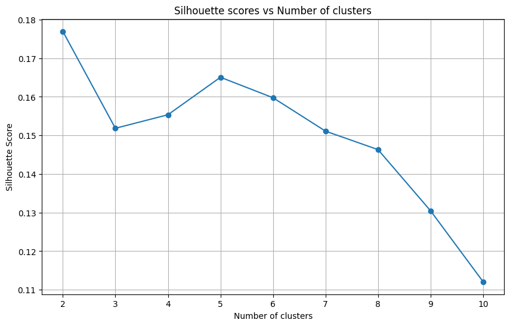

```python
#@title hierarchical clustering
from sklearn.metrics import silhouette_score
import matplotlib.pyplot as plt
from sklearn.cluster import AgglomerativeClustering

max_clusters = 10
silhouette_scores = []
for n_clusters in range(2, max_clusters + 1):
    agg_clustering = AgglomerativeClustering(n_clusters=n_clusters, affinity='manhattan', linkage='average')
    clusters = agg_clustering.fit_predict(merged_data_prepared)
    silhouette_scores.append(silhouette_score(merged_data_prepared, clusters))

# Plot the silhouette scores
plt.figure(figsize=(10, 6))
plt.plot(range(2, max_clusters + 1), silhouette_scores, marker='o')
plt.title('Silhouette scores vs Number of clusters')
plt.xlabel('Number of clusters')
plt.ylabel('Silhouette Score')
plt.grid(True)
plt.show()
```

```python
from sklearn.cluster import AgglomerativeClustering

# Create a model with 2 clusters
optimal_num_clusters = 2
agg_clustering = AgglomerativeClustering(n_clusters=optimal_num_clusters, affinity='manhattan', linkage='average')

# Train the model
clusters = agg_clustering.fit_predict(merged_data_prepared)

df_hcluster = merged_data.copy()
df_hcluster['hcluster'] = clusters

# Summary Statistics for each Cluster
summary = df_hcluster.groupby('hcluster').agg({'Age':'mean', 'Tenure':'mean', 'Avg_Session_Duration_min':'mean', 'No_of_Purchases':'mean', 'Click_To_Add_Ratio':'mean', 'Click_To_Add_Ratio':'mean'}).reset_index()
summary
```

|  | hcluster | Age | Tenure | Avg_Session_Duration_min | No_of_Purchases | Click_To_Add_Ratio |
| --- | --- | --- | --- | --- | --- | --- |
| 0 | 0 | 36.416031 | 3.583969 | 15.678477 | 74.679389 | 0.697012 |
| 1 | 1 | 36.321429 | 3.678571 | 16.002445 | 24.794118 | 0.686131 |

### 3.4 Now that we've determined our optimal number of clusters using hierarchical clustering, one way to visualize and further analyze the segmentation of our data is to use Principal Component Analysis (PCA). Utilize PCA to show the clustering result.

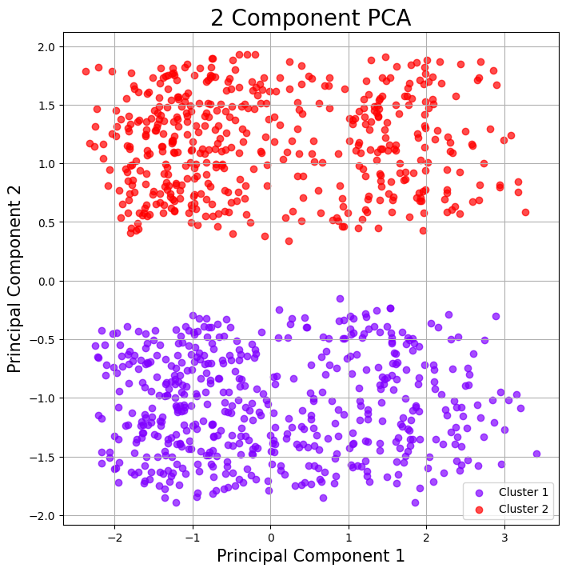

```python
from sklearn.decomposition import PCA
import matplotlib.cm as cm


# Perform PCA
pca = PCA(n_components=2)
principal_components = pca.fit_transform(merged_data_prepared)

# Create a DataFrame with the principal components
pca_df = pd.DataFrame(data=principal_components, columns=['Principal Component 1', 'Principal Component 2'])

# Add the cluster labels
pca_df['hCluster'] = clusters

# Plot the clusters
plt.figure(figsize=(8,8))
colors = cm.rainbow(np.linspace(0, 1, optimal_num_clusters))

for color, label in zip(colors, range(optimal_num_clusters)):
    plt.scatter(pca_df.loc[pca_df['hCluster'] == label, 'Principal Component 1'],
                pca_df.loc[pca_df['hCluster'] == label, 'Principal Component 2'],
                c=color,
                alpha=0.7,
                label=f'Cluster {label+1}')

plt.xlabel('Principal Component 1', fontsize=15)
plt.ylabel('Principal Component 2', fontsize=15)
plt.title('2 Component PCA', fontsize=20)
plt.legend()
plt.grid()
plt.show()
```

## 4. Predictive Modeling

### 4.1 As a data scientist, how would you incorporate the results from our clustering model, specifically the cluster assignments, into the K-NN model? Remember, the objective is to enhance our understanding of individual customer's behavior within the clusters.

```python
# Merge customer and customer_behavior
df_merge1 = pd.merge(customers, customer_behavior, on='Customer_Id')

# Merge df_merge1 and products
df_full = pd.merge(df_merge1, products, on='Product_Id')

# Merge df_full with df_cluster on 'Customer_Id' to add the cluster labels
df_full = pd.merge(df_full, df_hcluster[['Customer_Id', 'hcluster']], on='Customer_Id')

df_full.head()
```

|  | Customer_Id | Age | Gender | Location | Tenure | Avg_Session_Duration_min | No_of_Purchases | Product_Id | Clicked | Added_to_Cart | Purchased | Category | Brand | Price | Rating | hcluster |
| --- | --- | --- | --- | --- | --- | --- | --- | --- | --- | --- | --- | --- | --- | --- | --- | --- |
| 0 | 0 | 35 | F | City_B | 4 | 16.294556 | 87 | 216 | 1 | 1 | 0 | Electronic | Brand_E1 | 191.077879 | 4.4 | 0 |
| 1 | 0 | 35 | F | City_B | 4 | 16.294556 | 87 | 188 | 0 | 0 | 0 | Electronic | Brand_E1 | 268.635713 | 4.4 | 0 |
| 2 | 0 | 35 | F | City_B | 4 | 16.294556 | 87 | 445 | 1 | 0 | 0 | Groceries | Brand_G1 | 8.826173 | 3.8 | 0 |
| 3 | 0 | 35 | F | City_B | 4 | 16.294556 | 87 | 479 | 1 | 1 | 1 | Clothing | Brand_C3 | 60.871776 | 4.2 | 0 |
| 4 | 0 | 35 | F | City_B | 4 | 16.294556 | 87 | 304 | 1 | 1 | 1 | Beauty | Brand_B2 | 12.681781 | 3.6 | 0 |

### 4.2 The K-NN model is based on the concept of feature similarity. How can we ensure that all our features are compatible with this concept? What changes, if any, do we need to make to our dataset before applying K-NN?

```python
# Standardize numerical features for K-NN model
from sklearn.preprocessing import StandardScaler

df_transformed = df_full.copy()
features_to_scale = ['Age', 'Tenure', 'Avg_Session_Duration_min', 'No_of_Purchases', 'Price', 'Rating']
scaler = StandardScaler()
df_transformed[features_to_scale] = scaler.fit_transform(df_transformed[features_to_scale])

# Suppose 'Gender', 'Location', 'Category' and 'Brand' are categorical columns
categorical_cols = ['Gender', 'Location', 'Category', 'Brand', 'hcluster']

# Perform one-hot encoding
df_transformed = pd.get_dummies(df_transformed, columns=categorical_cols)
df_transformed.head()
```

|  | Customer_Id | Age | Tenure | Avg_Session_Duration_min | No_of_Purchases | Product_Id | Clicked | Added_to_Cart | Purchased | Price | ... | Brand_Brand_C1 | Brand_Brand_C2 | Brand_Brand_C3 | Brand_Brand_E1 | Brand_Brand_E2 | Brand_Brand_G1 | Brand_Brand_G2 | Brand_Brand_G3 | hcluster_0 | hcluster_1 |
| --- | --- | --- | --- | --- | --- | --- | --- | --- | --- | --- | --- | --- | --- | --- | --- | --- | --- | --- | --- | --- | --- |
| 0 | 0 | -0.094174 | 0.162082 | 0.065908 | 1.257315 | 216 | 1 | 1 | 0 | 0.974675 | ... | 0 | 0 | 0 | 1 | 0 | 0 | 0 | 0 | 1 | 0 |
| 1 | 0 | -0.094174 | 0.162082 | 0.065908 | 1.257315 | 188 | 0 | 0 | 0 | 1.649255 | ... | 0 | 0 | 0 | 1 | 0 | 0 | 0 | 0 | 1 | 0 |
| 2 | 0 | -0.094174 | 0.162082 | 0.065908 | 1.257315 | 445 | 1 | 0 | 0 | -0.610508 | ... | 0 | 0 | 0 | 0 | 0 | 1 | 0 | 0 | 1 | 0 |
| 3 | 0 | -0.094174 | 0.162082 | 0.065908 | 1.257315 | 479 | 1 | 1 | 1 | -0.157827 | ... | 0 | 0 | 1 | 0 | 0 | 0 | 0 | 0 | 1 | 0 |
| 4 | 0 | -0.094174 | 0.162082 | 0.065908 | 1.257315 | 304 | 1 | 1 | 1 | -0.576973 | ... | 0 | 0 | 0 | 0 | 0 | 0 | 0 | 0 | 1 | 0 |

5 rows × 38 columns

### 4.3 Selecting an optimal number of neighbors is a crucial aspect of the K-NN model. How would you go about this process? Could you outline an approach for selecting the best number of neighbors using cross-validation?

```python
from sklearn.model_selection import GridSearchCV
from sklearn.neighbors import KNeighborsClassifier

X = df_transformed.drop('Purchased', axis=1)
y = df_transformed['Purchased']

# Create a KNN classifier
knn = KNeighborsClassifier()

# Define our parameter grid
param_grid = {'n_neighbors': list(range(1, 20))}

# Grid Search to find optimal number of neighbors
knn_gscv = GridSearchCV(knn, param_grid, cv=5)
knn_gscv.fit(X, y)

# Print optimal number of neighbors
print(f"Optimal number of neighbors: {knn_gscv.best_params_['n_neighbors']}")
```

```
Optimal number of neighbors: 18
```

### 4.4 Once we have an optimal number of neighbors, we would need to assess the performance of our K-NN model. Could you build the model and propose a strategy to evaluate the model's performance?

```python
from sklearn.model_selection import train_test_split
from sklearn.preprocessing import StandardScaler
from sklearn.metrics import classification_report

# Split dataset into features (X) and target (y)
X = df_transformed.drop('Purchased', axis=1)
y = df_transformed['Purchased']

# Split the data into training set and test set
X_train, X_test, y_train, y_test = train_test_split(X, y, test_size=0.3, random_state=42)

# Determine best k (the one with the highest score)
optimal_k = 18

# Create KNN classifier
knn = KNeighborsClassifier(n_neighbors=optimal_k)

# Fit the classifier to the data
knn.fit(X_train, y_train)

# Predict the labels for the test data
y_pred = knn.predict(X_test)

# Print classification report
print(classification_report(y_test, y_pred))
```

```
              precision    recall  f1-score   support

           0       0.77      1.00      0.87      2311
           1       0.00      0.00      0.00       689

    accuracy                           0.77      3000
   macro avg       0.38      0.50      0.43      3000
weighted avg       0.59      0.77      0.67      3000
```

### 4.5 Given the imbalanced nature of our target variable 'Purchased', applying predictive models directly could result in poor performance, especially for the minority class. The model simply predicts 0 for all the data points in minority class, while those data points have a value of "1". This could have a huge impact on our business since it would mean that non of the customer is predicted to purchase any product. Can you describe how techniques like SMOTE or ADASYN can help address this issue? Demonstrate how you would apply these techniques to balance our data.

```python
#@title SMOTE
from imblearn.over_sampling import SMOTE

# Split dataset into features (X) and target (y)
X = df_transformed.drop('Purchased', axis=1)
y = df_transformed['Purchased']

# Split the data into training set and test set
X_train, X_test, y_train, y_test = train_test_split(X, y, test_size=0.3, random_state=42)

smote = SMOTE(sampling_strategy='minority', random_state=42)
X_train_res, y_train_res = smote.fit_resample(X_train, y_train)

# Determine best k (the one with the highest score)
optimal_k = 18

# Create KNN classifier
knn = KNeighborsClassifier(n_neighbors=optimal_k)

# Fit the classifier to the data
knn.fit(X_train_res, y_train_res)

# Predict the labels for the test data
y_pred = knn.predict(X_test)

# Print classification report
print(classification_report(y_test, y_pred))
```

```
              precision    recall  f1-score   support

           0       0.78      0.61      0.68      2311
           1       0.24      0.42      0.31       689

    accuracy                           0.56      3000
   macro avg       0.51      0.51      0.49      3000
weighted avg       0.65      0.56      0.59      3000
```

```python
#@title ADASYN
from imblearn.over_sampling import ADASYN

# Split dataset into features (X) and target (y)
X = df_transformed.drop('Purchased', axis=1)
y = df_transformed['Purchased']

# Split the data into training set and test set
X_train, X_test, y_train, y_test = train_test_split(X, y, test_size=0.3, random_state=42)

adasyn = ADASYN(sampling_strategy='minority', random_state=42)
X_train_res, y_train_res = adasyn.fit_resample(X_train, y_train)

# Determine best k (the one with the highest score)
optimal_k = 18

# Create KNN classifier
knn = KNeighborsClassifier(n_neighbors=optimal_k)

# Fit the classifier to the data
knn.fit(X_train_res, y_train_res)

# Predict the labels for the test data
y_pred = knn.predict(X_test)

# Print classification report
print(classification_report(y_test, y_pred))
```

```
              precision    recall  f1-score   support

           0       0.77      0.60      0.68      2311
           1       0.23      0.40      0.29       689

    accuracy                           0.56      3000
   macro avg       0.50      0.50      0.49      3000
weighted avg       0.65      0.56      0.59      3000
```

### 4.6 Resampling techniques like Synthetic Minority Over-sampling Technique (SMOTE) or Adaptive Synthetic Sampling (ADASYN) can be valuable tools for mitigating these issues. Could you also demonstrate how we can utilize these approaches, possibly in conjunction with under-sampling of the majority class, to improve our model's performance?

```python
from imblearn.over_sampling import SMOTE
from imblearn.under_sampling import RandomUnderSampler
from imblearn.pipeline import Pipeline

# Define pipeline
over = SMOTE(sampling_strategy=1.0)  # Over-sample the minority class to equal the majority class
under = RandomUnderSampler(sampling_strategy=1.0)  # Under-sample the majority class to equal the minority class
steps = [('o', over), ('u', under)]
pipeline = Pipeline(steps=steps)

# Apply pipeline
X_res, y_res = pipeline.fit_resample(X_train, y_train)

# Create KNN classifier
knn = KNeighborsClassifier(n_neighbors=optimal_k)

# Fit the classifier to the data
knn.fit(X_res, y_res)

# Predict the labels for the test data
y_pred = knn.predict(X_test)

# Print classification report
print(classification_report(y_test, y_pred))
```

```
              precision    recall  f1-score   support

           0       0.78      0.59      0.67      2311
           1       0.24      0.43      0.31       689

    accuracy                           0.56      3000
   macro avg       0.51      0.51      0.49      3000
weighted avg       0.65      0.56      0.59      3000
```

## 5. Business Problems

### 5.1 Suppose you've built a KNN model to predict whether a customer will purchase a product. How could you use the insights from this model to inform our business strategy? For instance, how could the model's predictions guide our product recommendation system, marketing efforts, or customer retention strategies?

The KNN model's predictions could be used to inform several aspects of the business strategy. For instance:

- Product Recommendation: Products that are likely to be purchased (based on the model's predictions) could be highlighted or recommended to the customer.
- Marketing: The business could target marketing or promotional efforts towards customers who are predicted to be on the fence about purchasing a product.
- Customer Retention: The business could proactively reach out to customers who are predicted not to purchase, in order to understand their concerns and try to retain them.